# Emprego e renda no Brasil

## Resultado de agosto de 2026

**Dados divulgados pelo IBGE e obtidos no Banco Central em 05/10/2026.**

**NotaDesemprego: 5,3%**

Em relação ao mês anterior, ficou igual (5,3% em julho de 2026). Em relação a doze meses atrás, caiu 0,3 ponto percentual (era 5,6% em agosto de 2025).

**NotaRendimento médio: R$ 3.660 por mês**

Em relação ao mês anterior, subiu R$ 17, ou 0,5% (era R$ 3.643 em julho de 2026). Em relação a doze meses atrás, subiu R$ 125, ou 3,5% (era R$ 3.535 em agosto de 2025).

## O que esses números medem

A **taxa de desemprego** é a parcela das pessoas que procuraram trabalho e não encontraram, entre todas as que estão trabalhando ou procurando trabalho. Quem não procura emprego, como estudantes que só estudam ou aposentados, fica fora da conta.

O **rendimento médio real** é quanto, em média, uma pessoa que trabalha ganha por mês com todos os seus trabalhos. A palavra “real” quer dizer que a inflação já foi descontada: os valores de meses antigos estão corrigidos para o poder de compra de hoje, e por isso dá para comparar épocas diferentes.

Os dois números vêm da PNAD Contínua, a pesquisa do IBGE que entrevista famílias em todo o país. O resultado de agosto de 2026 é a média dos três meses de junho a agosto de 2026. Por isso a mudança de um mês para o outro costuma ser pequena.

## Como os números evoluíram desde março de 2012

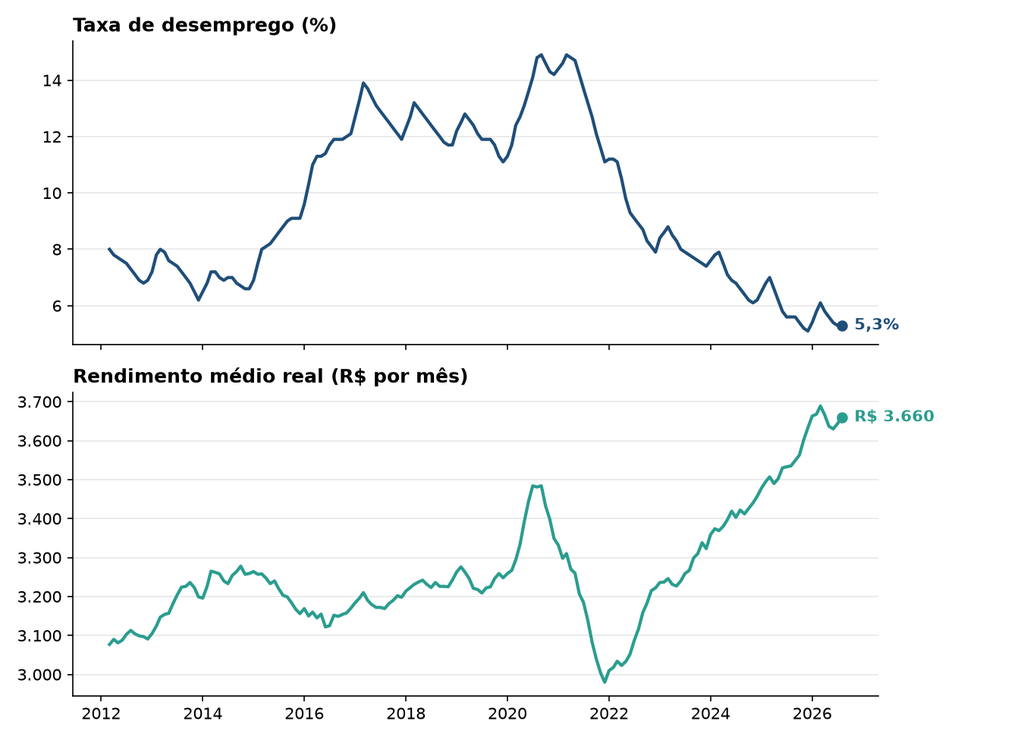

Fonte: IBGE, PNAD Contínua, obtida no Sistema Gerenciador de Séries Temporais (SGS) do Banco Central, séries 24369 e 24382.